# More GIS in R: tracts to HRAs

# 4 Assign tracts to HRAs: `sp::over()`

```r
vignette("over")

kc_tracts_poly$acs5_2009 <- spTransform(kc_tracts_poly$acs5_2009,
                                        kc_tracts_poly$acs5_2019@proj4string)


tracts_to_hra <- list()

for(yr in years){
  yr.idx <- match(yr, years)

  tracts_to_hra[[paste0("acs5_", yr)]] <-
    over(kc_tracts_poly[[paste0("acs5_", yr)]],
         hra, returnList = TRUE)
  n.tracts <- length(tracts_to_hra[[yr.idx]])
  nested.idx <- unlist(lapply(tracts_to_hra[[paste0("acs5_", yr)]],
                              function(x){
                                nrow(x) == 1
                              }))
  kc_tracts_poly[[paste0("acs5_", yr)]]$nested_in_hra <- 0
  kc_tracts_poly[[paste0("acs5_", yr)]]$nested_in_hra[nested.idx] <- 1

  for(tract.idx in 1:n.tracts){
    tracts_to_hra[[yr.idx]][[tract.idx]]$prop.area <- NA
    tracts_to_hra[[yr.idx]][[tract.idx]]$total.area <- NA
    tracts_to_hra[[yr.idx]][[tract.idx]]$total.minus.sum <- NA

    tracts_to_hra[[yr.idx]][[tract.idx]]$tract.idx <- tract.idx
    if(nested.idx[tract.idx]){
      tracts_to_hra[[yr.idx]][[tract.idx]]$prop.area <- 1
      tracts_to_hra[[paste0("acs5_", yr)]][[tract.idx]]$total.sum <-
        tracts_to_hra[[paste0("acs5_", yr)]][[tract.idx]]$total.area <-
        area(kc_tracts_poly[[yr.idx]][tract.idx,])

      tracts_to_hra[[paste0("acs5_", yr)]][[tract.idx]]$total.minus.sum <-
        (tracts_to_hra[[paste0("acs5_", yr)]][[tract.idx]]$total.area[1] -
           sum(tract.areas))/(sum(tract.areas))
    }else{
      hras.for.tract <- tracts_to_hra[[paste0("acs5_", yr)]][[tract.idx]]$FID_HRA_20
      tract.areas <- rep(NA, length(hras.for.tract))
      for(hra.no in hras.for.tract){
        hra.idx <- match(hra.no, hras.for.tract)

        ## Calculate area of intersections
        tract.areas[hra.idx] <- area(intersect(kc_tracts_poly[[yr.idx]][tract.idx,],
                                               hra[hra$FID_HRA_20 == hra.no,]))
      }
      tracts_to_hra[[paste0("acs5_", yr)]][[tract.idx]]$prop.area <-
        tract.areas/sum(tract.areas)
      tracts_to_hra[[paste0("acs5_", yr)]][[tract.idx]]$total.sum <-
        tract.areas/sum(tract.areas)
      tracts_to_hra[[paste0("acs5_", yr)]][[tract.idx]]$total.area <-
        area(kc_tracts_poly[[yr.idx]][tract.idx,])

      tracts_to_hra[[paste0("acs5_", yr)]][[tract.idx]]$total.minus.sum <-
        (tracts_to_hra[[paste0("acs5_", yr)]][[tract.idx]]$total.area[1] -
           sum(tract.areas))/(sum(tract.areas))
    }
  }

  transform.df <- do.call(rbind.data.frame,
                          tracts_to_hra[[yr.idx]])

  transform.df$GEOID <- kc_tracts_poly[[yr.idx]]$GEOID[transform.df$tract.idx]

  kc_tracts_poly[[yr.idx]]@data <- kc_tracts_poly[[yr.idx]]@data %>%
    left_join(transform.df %>%
                dplyr::select(-COUNTY,
                              -STATE,
                              -CNTYN,
                              -CNTY,
                              -FIPS))
}
```

## 4.1 Save data.frames

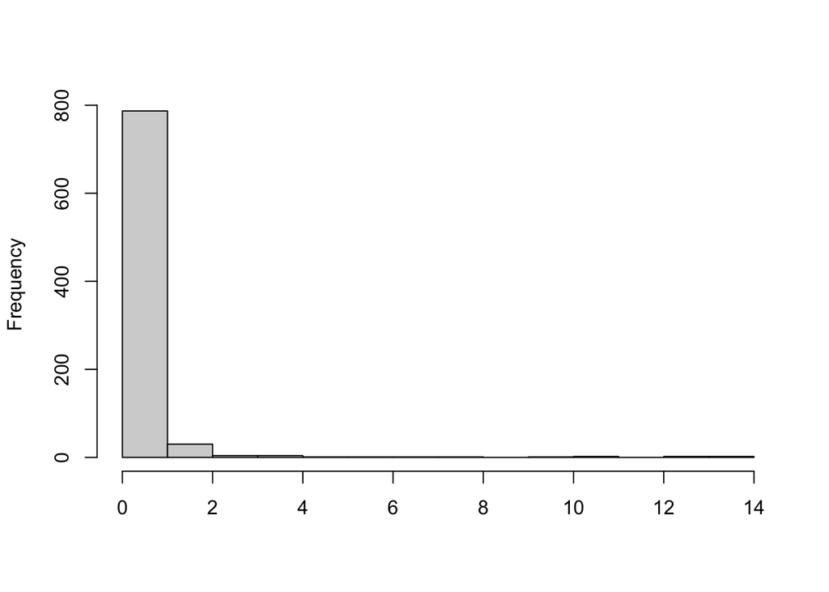

```r
## Need to dig into the few weirdos
hist(abs(unlist(lapply(tracts_to_hra$acs5_2019, function(x){
  x$total.minus.sum
}))),
main = "",
xlab = "")
```

```r
tracts_to_hra <- lapply(tracts_to_hra,
                        function(x){
                          do.call(rbind.data.frame,x)
                        })

for(year in years){
  list.name <- paste0("acs5_", year)
  tracts_to_hra[[list.name]]$GEOID <-
    kc_tracts_poly[[list.name]]@data$GEOID[tracts_to_hra[[list.name]]$tract.idx]
}
save(tracts_to_hra, file = '../Data/tracts_to_hra.rda')
```

# 5 An example: HRA Population

```r
## How to load a .rda
# load('../Data/tracts_to_hra.rda')
# years <- seq(2019, 2009, -5)

pop_by_hra <- list()
for(year in years){


  pop_by_hra[[paste0("acs5_", year)]] <-
    ## take tracts_to_hra file and left_join()
    ## my variable from the cnesus
    tracts_to_hra[[paste0("acs5_", year)]] %>%
    left_join(kc_tracts_poly[[paste0("acs5_", year)]]@data %>%
                dplyr::select(GEOID, estimate, moe)) %>%

    ## group_by() HRA and get a weighted sum
    ## of tract contributions to HRA
    group_by(FID_HRA_20) %>%
    summarise(estimate = sum(prop.area*estimate),
              moe = sum(prop.area*moe)) %>%
    mutate(SE = moe/qnorm(.95),
           CoV = SE/estimate)
  ## Make sure data frames follow ordering of shapefile
  reorder.idx <- match(pop_by_hra[[paste0("acs5_", year)]]$FID_HRA_20,
                       hra@data$FID_HRA_20)
  pop_by_hra[[paste0("acs5_", year)]] <-
    pop_by_hra[[paste0("acs5_", year)]][reorder.idx,]

  kc_tracts_poly[[paste0("acs5_", year)]]@data <-
    kc_tracts_poly[[paste0("acs5_", year)]]@data %>%
    mutate(SE = moe/qnorm(.95),
           CoV = SE/estimate)
}
lapply(kc_tracts, function(x){
  range(x$estimate)
})
```

```
## $acs5_2019
## [1]     0 15208
##
## $acs5_2014
## [1]     0 12105
##
## $acs5_2009
## [1]  1209 13989
```

```r
lapply(pop_by_hra, function(x){
  range(x$estimate)
})
```

```
## $acs5_2019
## [1]  15002.0 216926.1
##
## $acs5_2014
## [1]  23968.44 248561.81
##
## $acs5_2009
## [1]  22740.0 237396.6
```

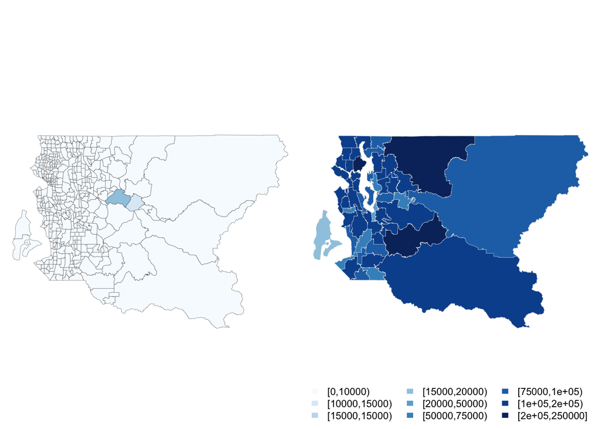

```r
## Pick R Color Brewer palette
pop.pal <- brewer.pal(9, "Blues")
## Get one estimate for each tract (remember this data frame)
## Is now longer bc it is one row per tract/hra intersection
pop.tract.vector <- unique(kc_tracts_poly$acs5_2019@data[, c("GEOID", "estimate")])

## assign each population to bin defined in fixed breaks
pop.int.tract <- classIntervals(pop.tract.vector$estimate,
                                style = 'fixed',
                                fixedBreaks = c(0, 10000,
                                                15000, 20000,
                                                50000, 75000,
                                                100000, 15000,
                                                200000, 250000),
                                n = 9)

pop.int.hra <- classIntervals(pop_by_hra$acs5_2019$estimate,
                              style = 'fixed',
                              fixedBreaks = c(0, 10000,
                                              15000, 20000,
                                              50000, 75000,
                                              100000, 15000,
                                              200000, 250000),
                              n = 9)

## Get color based on RColorBrwere palette for
## each area
pop.col.tract <- findColours(pop.int.tract, pop.pal)
pop.col.hra <- findColours(pop.int.hra, pop.pal)

## Plot

par(mfrow = c(1,2),
    mar = c(0,0,2,0) + 0.1,
    oma = c(0,0,0,0))

plot(kc_tracts_poly$acs5_2019,
     col = pop.col.tract,
     border = 'grey28', lwd = .25)
plot(hra,
     col = pop.col.hra,
     border = 'grey88', lwd = .25)

legend('bottomleft',
       ncol = 3,
       bty = 'n',
       cex = 0.7,
       border = FALSE,
       fill = pop.pal,
       legend = names(attr(pop.col.hra, 'table')))
```

```r
pdf("../PopPlots/TotalPop_2019_HRA.pdf",
    height = 4,width = 4)

par(mfrow = c(1,1),
    mar = c(0,0,0,0),
    oma = c(0,0,0,0))
plot(hra,
     col = pop.col.hra,
     border = 'grey88', lwd = .25)

legend('bottomleft',
       ncol = 3,
       bty = 'n',
       cex = 0.7,
       border = FALSE,
       fill = pop.pal,
       legend = names(attr(pop.col.hra, 'table')))

dev.off()
```

```r
pdf("../PopPlots/TotalPop_Carnation_2019_HRA.pdf",
    height = 4,width = 4)

par(mfrow = c(1,1),
    mar = c(0,0,0,0),
    oma = c(0,0,0,0))
plot(hra,
     col = pop.col.hra,
     border = 'grey88', lwd = .25)
plot(hra[5,],
     add = TRUE,
     border = 'firebrick')

legend('bottomleft',
       ncol = 3,
       bty = 'n',
       cex = 0.7,
       border = FALSE,
       fill = pop.pal,
       legend = names(attr(pop.col.hra, 'table')))

dev.off()
```

```r
pdf("../PopPlots/TotalPop_Snoqualmie_2019_HRA.pdf",
    height = 4,width = 4)

par(mfrow = c(1,1),
    mar = c(0,0,0,0),
    oma = c(0,0,0,0))
plot(hra,
     col = pop.col.hra,
     border = 'grey88', lwd = .25)
plot(hra[46,],
     add = TRUE,
     border = 'firebrick')

legend('bottomleft',
       ncol = 3,
       bty = 'n',
       cex = 0.7,
       border = FALSE,
       fill = pop.pal,
       legend = names(attr(pop.col.hra, 'table')))

dev.off()
```

```r
pop.int.hra <- classIntervals(pop_by_hra$acs5_2009$estimate,
                              style = 'fixed',
                              fixedBreaks = c(0, 10000,
                                              15000, 20000,
                                              50000, 75000,
                                              100000, 15000,
                                              200000, 250000),
                              n = 9)

## Get color based on RColorBrwere palette for
## each area

pop.col.hra <- findColours(pop.int.hra, pop.pal)

pdf("../PopPlots/TotalPop_2009_HRA.pdf",
    height = 4,width = 4)

par(mfrow = c(1,1),
    mar = c(0,0,0,0),
    oma = c(0,0,0,0))
plot(hra,
     col = pop.col.hra,
     border = 'grey88', lwd = .25)

legend('bottomleft',
       ncol = 3,
       bty = 'n',
       cex = 0.7,
       border = FALSE,
       fill = pop.pal,
       legend = names(attr(pop.col.hra, 'table')))

dev.off()
```

## 5.1 Population by age x time

First, load the variable labels and fix up/transform the `label` column into more usable variables for me `age_short`, `age_lower`, `age_upper`.

```r
var_df <- load_variables(2019, "acs5", cache = TRUE)
var_df <- var_df[grepl("B01001", var_df$name),]


## Split the var_df$label column everywhere there is a "!!"
lab_splits <- strsplit(var_df$label, "!!")
head(lab_splits)
```

```
## [[1]]
## [1] "Estimate" "Total:"
##
## [[2]]
## [1] "Estimate" "Total:"   "Male:"
##
## [[3]]
## [1] "Estimate"      "Total:"        "Male:"         "Under 5 years"
##
## [[4]]
## [1] "Estimate"     "Total:"       "Male:"        "5 to 9 years"
##
## [[5]]
## [1] "Estimate"       "Total:"         "Male:"          "10 to 14 years"
##
## [[6]]
## [1] "Estimate"       "Total:"         "Male:"          "15 to 17 years"
```

```r
## Based on the length of each element of lab_splits,
## e.g. look at lab_splits[[1]] lab_splits[[10]]
## take the vector element I want (age group!)

age_elems <- unlist(lapply(lab_splits, function(x){
  if(length(x) == 4){
    x[4]
  }else if(length(x) == 3){
    x[3]
  }else{
    x[2]
  }
})
)
head(age_elems)
```

```
## [1] "Total:"         "Male:"          "Under 5 years"  "5 to 9 years"
## [5] "10 to 14 years" "15 to 17 years"
```

```r
## Replace all colons in age_elems
var_df$age_short <- gsub(":", "", age_elems)

## How many observations by each age?
## What do the age group strings look like?
table(var_df$age_short)
```

```
##
##    10 to 14 years    15 to 17 years   18 and 19 years    20 to 24 years
##                20                20                20                18
##          20 years          21 years    22 to 24 years    25 to 29 years
##                 2                 2                 2                20
##    30 to 34 years    35 to 39 years    35 to 44 years    40 to 44 years
##                20                 2                18                 2
##    45 to 49 years    45 to 54 years      5 to 9 years    50 to 54 years
##                 2                18                20                 2
##    55 to 59 years    55 to 64 years   60 and 61 years    62 to 64 years
##                 2                18                 2                 2
##   65 and 66 years    65 to 74 years    67 to 69 years    70 to 74 years
##                 2                18                 2                 2
##    75 to 79 years    75 to 84 years    80 to 84 years 85 years and over
##                 2                18                 2                20
##            Female              Male             Total     Under 5 years
##                10                10                10                20
```

```r
## Split the strings on " to " as it's the most
## common age group definition time "XX to XX years"
age_elems <- strsplit(age_elems, " to ")

var_df$age_upper <- unlist(lapply(age_elems, function(x){
  if(length(x) == 2){
    ## All "XX to XX years" fit this logical test
    gsub(" years", "", x[2])
  }else if(x == "Under 5 years"){
    "4"
  }else{
    ## Should add more cases but decide to
    ## use age_lower as my lookup variable
    NA
  }
}))

var_df$age_lower <- unlist(lapply(age_elems, function(x){
  if(length(x) == 2){
    ## All "XX to XX years" fit this logical test
    gsub(" years", "", x[1])

    ## Begin special cases
  }else if(x == "Under 5 years"){
    "0"
  }else if(x == "85 years and over"){
    "85"
  }else if(x == "18 and 19 years"){
    "18"
  }else if(x == "20 years"){
    "20"
  }else if(x == "21 years"){
    "21"
  }else{
    NA
  }
}))

head(var_df)
```

```
## # A tibble: 6 x 6
##   name      label                      concept  age_short    age_upper age_lower
##   <chr>     <chr>                      <chr>    <chr>        <chr>     <chr>
## 1 B01001_0… Estimate!!Total:           SEX BY … Total        <NA>      <NA>
## 2 B01001_0… Estimate!!Total:!!Male:    SEX BY … Male         <NA>      <NA>
## 3 B01001_0… Estimate!!Total:!!Male:!!… SEX BY … Under 5 yea… 4         0
## 4 B01001_0… Estimate!!Total:!!Male:!!… SEX BY … 5 to 9 years 9         5
## 5 B01001_0… Estimate!!Total:!!Male:!!… SEX BY … 10 to 14 ye… 14        10
## 6 B01001_0… Estimate!!Total:!!Male:!!… SEX BY … 15 to 17 ye… 17        15
```

Now that the labels are all cleaned up and I understand how ages are binned, I want to make my own columns which are indicators combining the census age groups into meaningful age groups.

```r
age_vars <- var_df %>%
  filter(concept == "SEX BY AGE") %>%
  drop_na(age_lower) %>%
  mutate(age_lower = as.numeric(age_lower)) %>%
  mutate(old.idx = ifelse(age_lower >= 65, 1, 0),
         child.idx = ifelse(age_lower >= 0 &
                              age_lower < 15, 1, 0),
         teen.idx = ifelse(age_lower >= 15 &
                             age_lower < 20, 1, 0),
         twenties.idx = ifelse(age_lower >= 20 &
                                 age_lower < 30, 1, 0),
         thirties.idx = ifelse(age_lower >= 30 &
                                 age_lower < 40, 1, 0),
         forties.idx = ifelse(age_lower >= 40 &
                                age_lower < 50, 1, 0),
         fifties.idx = ifelse(age_lower >= 50 &
                                age_lower < 60, 1, 0),
         sixties.idx = ifelse(age_lower >= 60 &
                                age_lower < 70, 1, 0),
         seventies.idx = ifelse(age_lower >= 70 &
                                  age_lower < 80, 1, 0),
         eightiesup.idx = ifelse(age_lower >= 80, 1, 0)) %>%
  as.data.frame()


## Make sure the ages_var table age_lower column
## looks like what I expect and want
ageslow <- unique(age_vars$age_lower)
ageslow
```

```
##  [1]  0  5 10 15 18 20 21 22 25 30 35 40 45 50 55 62 67 70 75 80 85
```

Now, following the example above, I’ll convert the tract data to health reporting areas.

```r
pop_by_age_tracts <-
  pop_by_agegroup_tracts <- list()
pop_by_age_hra <-
  pop_by_agegroup_hra <- list()

for(yr in years){

  ## Pull data from ACS
  ## NOTE: geometry = FALSE, because
  ## I will use the geometries loaded previously
  ## This saves memory and computation time!
  ## But if you want to work in ggplot(), sf() framework
  ## Loading them all as geometries makes sense
  pop_by_age_tracts[[paste0("acs5_",yr)]] <- get_acs("tract",
                                                     table = "B01001",
                                                     geometry = FALSE,
                                                     year = yr,
                                                     survey = "acs5",
                                                     state = "WA",
                                                     county = "King",
                                                     cache_table = TRUE) %>%

    ## Merge the age_vars table
    ## to use my fancy new labels
    left_join(age_vars,
              by = c("variable" = "name")) %>%

    ## Drop "Total", "Male", "Female"
    drop_na(age_short) %>%
    ## Calculate SE from moe
    mutate(SE = moe/qnorm(.95)) %>%

    ## Sum over sexes,
    ## calculate CoV
    group_by(GEOID, age_short) %>%
    summarise(estimate = sum(estimate),
              SE = sum(SE),
              CoV = SE/estimate,
              age_lower = unique(age_lower))


  ## Do it again for my custom age groups
  ## Would maybe be best to fold this into code above, BUT

  pop_by_agegroup_tracts[[paste0("acs5_",yr)]] <- get_acs("tract",
                                                          table = "B01001",
                                                          geometry = FALSE,
                                                          year = yr,
                                                          survey = "acs5",
                                                          state = "WA",
                                                          county = "King",
                                                          cache_table = TRUE) %>%

    ## Merge the age_vars table
    ## to use my fancy new labels
    left_join(age_vars,
              by = c("variable" = "name")) %>%

    ## Drop "Total", "Male", "Female"
    drop_na(age_short) %>%
    ## Calculate SE from moe
    mutate(SE = moe/qnorm(.95))

  ## Do special groups in a loop
  tmp.names.idx <- names(pop_by_agegroup_tracts[[paste0("acs5_",yr)]])[
    grep("idx", names(pop_by_agegroup_tracts[[paste0("acs5_", yr)]]))]

  for(group in tmp.names.idx){
    tmp.colname <- gsub("\\.idx", "", group)
    ## Do estimate for special group
    pop_by_agegroup_tracts[[paste0("acs5_",yr)]][ , paste0(tmp.colname,
                                                           "_estimate")] <-
      pop_by_agegroup_tracts[[paste0("acs5_",yr)]]$estimate*
      pop_by_agegroup_tracts[[paste0("acs5_",yr)]][ , group]
    ## Do MOE for special group
    pop_by_agegroup_tracts[[paste0("acs5_",yr)]][ , paste0(tmp.colname,
                                                           "_SE")] <-
      pop_by_agegroup_tracts[[paste0("acs5_",yr)]]$SE*
      pop_by_agegroup_tracts[[paste0("acs5_",yr)]][ , group]
  }


  pop_by_agegroup_tracts[[paste0("acs5_",yr)]] <-
    pop_by_agegroup_tracts[[paste0("acs5_",yr)]] %>%

    pivot_longer(cols = ends_with(c("_estimate", "_SE")),
                 names_to = c("agegroup", "metric"),
                 names_sep = "_",
                 values_to = "metric_val",
                 values_drop_na = FALSE) %>%
    pivot_longer(cols = ends_with("idx"),
                 names_to = c("idxagegroup", "idx"),
                 names_sep = "\\.",
                 values_to = "idx_val",
                 values_drop_na = FALSE) %>%
    filter(idx_val == 1) %>%
    filter(agegroup == idxagegroup) %>%
    dplyr::select(-estimate, -moe) %>%
    ## Sum over sexes,
    group_by(GEOID, agegroup,
             metric) %>%
    summarise(metric_val = sum(metric_val),
              age_lower = min(age_lower)) %>%
    pivot_wider(names_from ="metric",
                values_from = "metric_val") %>%
    arrange(age_lower)

  ## Use tracts_to_hra data.frames and the
  ## tracts_to_hra$acs5_YYYY$prop.area
  ## column to aggregate up to HRAs
  pop_by_age_hra[[paste0("acs5_",yr)]] <-
    tracts_to_hra[[paste0("acs5_", yr)]] %>%
    left_join(pop_by_age_tracts[[paste0("acs5_",yr)]]) %>%

    ## group_by() HRA and AGE (not used in previous example)
    ## to get a weighted sum
    ## of tract contributions to HRA
    group_by(FID_HRA_20, age_short) %>%
    summarise(estimate = sum(prop.area*estimate),
              SE = sum(prop.area*SE),
              age_lower = unique(age_lower)) %>%
    mutate(CoV = SE/estimate)

  pop_by_agegroup_hra[[paste0("acs5_",yr)]] <-
    tracts_to_hra[[paste0("acs5_", yr)]] %>%
    left_join(pop_by_agegroup_tracts[[paste0("acs5_",yr)]]) %>%
    ## group_by() HRA and AGE (not used in previous example)
    ## to get a weighted sum
    ## of tract contributions to HRA
    group_by(FID_HRA_20, HRA2010v2_,
             agegroup, age_lower) %>%
    summarise(estimate = sum(prop.area*estimate),
              SE = sum(prop.area*SE)) %>%
    mutate(CoV = SE/estimate)
}
```

```
## Loading ACS5 variables for 2019 from table B01001 and caching the dataset for faster future access.
```

```
## Loading ACS5 variables for 2019 from table B01001 and caching the dataset for faster future access.
```

```
## Loading ACS5 variables for 2014 from table B01001 and caching the dataset for faster future access.
```

```
## Loading ACS5 variables for 2014 from table B01001 and caching the dataset for faster future access.
```

```
## Loading ACS5 variables for 2009 from table B01001 and caching the dataset for faster future access.
```

```
## Loading ACS5 variables for 2009 from table B01001 and caching the dataset for faster future access.
```

```r
save(pop_by_agegroup_hra,
     pop_by_age_hra,
     pop_by_agegroup_tracts,
     pop_by_age_tracts,
     file = paste0('ACS5_ests_hra_and_tract.rda'))
```

### 5.1.1 Plots in a loop

#### 5.1.1.1 Census age groups

```r
## Check output to see ranges for custom label ranges
## and to make sure there's no funny business
lapply(pop_by_age_tracts, function(x){
  print(range(x$estimate))
  print(range(x$CoV))
})
```

```
## [1]    0 3888
## [1] 0.09666747        Inf
## [1]    0 3560
## [1] 0.111992      Inf
## [1]    0 3510
## [1] 0.1071346       Inf
```

```
## $acs5_2019
## [1] 0.09666747        Inf
##
## $acs5_2014
## [1] 0.111992      Inf
##
## $acs5_2009
## [1] 0.1071346       Inf
```

```r
lapply(pop_by_age_hra, function(x){
  print(range(x$estimate))
  print(range(x$CoV))
})
```

```
## [1]    40.00 10392.48
## [1] 0.1631001 1.1818949
## [1]   65.000 8874.022
## [1] 0.2047576 1.2071115
## [1]    36.78574 12375.65393
## [1]  0.1771332 14.8275223
```

```
## $acs5_2019
## [1] 0.1631001 1.1818949
##
## $acs5_2014
## [1] 0.2047576 1.2071115
##
## $acs5_2009
## [1]  0.1771332 14.8275223
```

```r
## Pick R Color Brewer palette
pop.pal <- brewer.pal(9, "Blues")
cov.pal <- brewer.pal(9, "Reds")
## Get one estimate for each tract (remember this data frame)
## Is now longer bc it is one row per tract/hra intersection

breaks_by_age <- list()
cov_by_age <- list()
for(yr in years){
  for(agelow in as.numeric(ageslow)){
    agelabel <- unique(age_vars$age_short[age_vars$age_lower == agelow])
    pop.tract.vector <- pop_by_age_tracts[[paste0("acs5_", yr)]] %>%
      filter(age_lower == agelow) %>%
      mutate(CoV = if_else(is.finite(CoV),
                           CoV, 100)) %>%
      as.data.frame()


    pop.hra.vector <- pop_by_age_hra[[paste0("acs5_", yr)]] %>%
      filter(age_short == agelabel) %>%
      as.data.frame() %>% unique()


    ## assign each population to bin defined in fixed breaks
    if(match(yr, years) == 1){
      pop.int.tract <- classIntervals(c(pop.tract.vector$estimate,
                                        pop.hra.vector$estimate) + 50,
                                      style = 'jenks', n = 9)
      cov.int.tract <- classIntervals(pop.tract.vector$CoV,
                                      style = 'jenks', n = 9)

      breaks_by_age[[unique(pop.hra.vector$age_short)]] <- c(0, pop.int.tract$brks[-1])
      cov_by_age[[unique(pop.hra.vector$age_short)]] <- round(c(0, cov.int.tract$brks[-1]), 2)
    }
    pop.int.tract <- classIntervals(pop.tract.vector$estimate,
                                    style = 'fixed',
                                    fixedBreaks = breaks_by_age[[unique(pop.hra.vector$age_short)]],
                                    n = 9)
    cov.int.tract <- classIntervals(pop.tract.vector$CoV,
                                    style = 'fixed',
                                    fixedBreaks = cov_by_age[[unique(pop.hra.vector$age_short)]],
                                    n = 9)
    pop.int.hra <- classIntervals(pop.hra.vector$estimate,
                                  style = 'fixed',
                                  fixedBreaks = breaks_by_age[[unique(pop.hra.vector$age_short)]],
                                  n = 9)
    cov.int.hra <- classIntervals(pop.hra.vector$CoV,
                                  style = 'fixed',
                                  fixedBreaks = cov_by_age[[unique(pop.hra.vector$age_short)]],
                                  n = 9)


    ## Get color based on RColorBrwere palette for
    ## each area
    pop.col.tract <- findColours(pop.int.tract, pop.pal)
    pop.col.hra <- findColours(pop.int.hra, pop.pal)
    cov.col.tract <- findColours(cov.int.tract, cov.pal)
    cov.col.hra <- findColours(cov.int.hra, cov.pal)

    ## Plot
    pdf(paste0("../PopPlots/CensusAges/ACS5_",
               yr, "_age", agelow,
               ".pdf"),
        height = 8, width = 8)

    plot(kc_tracts_poly[[paste0("acs5_",yr)]],
         col = pop.col.tract,
         border = 'grey48', lwd = .25,
         main = "Population")
    plot(hra,
         col = pop.col.hra,
         border = 'grey88', lwd = .25)

    legend('bottomleft',
           ncol = 3,
           bty = 'n',
           cex = 0.7,
           border = FALSE,
           fill = pop.pal,
           legend = names(attr(pop.col.hra, 'table')))
    plot(kc_tracts_poly[[paste0("acs5_",yr)]],
         col = cov.col.tract,
         main = "Coefficient of Variation",
         border = 'grey88', lwd = .25)

    plot(hra,
         col = cov.col.hra,
         border = 'grey48', lwd = .25)


    legend('bottomleft',
           ncol = 3,
           bty = 'n',
           cex = 0.7,
           border = FALSE,
           fill = cov.pal,
           legend = names(attr(cov.col.hra, 'table')))
    dev.off()
  }
}
```

[output not shown]

[output cut: 40 more lines]

[output not shown]

```r
breaks_by_agegroup <- list()
cov_by_agegroup <- list()
for(yr in years){
  for(agelabel in unique(pop_by_agegroup_hra$acs5_2019$agegroup)){
    agelow <- unique(pop_by_agegroup_hra$acs5_2019$age_lower[
      pop_by_agegroup_hra$acs5_2019$agegroup == agelabel])
    pop.tract.vector <- pop_by_agegroup_tracts[[paste0("acs5_", yr)]] %>%
      filter(age_lower == agelow) %>%
      mutate(CoV = if_else(estimate > 0,
                           SE/estimate, 100)) %>%
      as.data.frame()


    pop.hra.vector <- pop_by_agegroup_hra[[paste0("acs5_", yr)]] %>%
      filter(agegroup == agelabel) %>%
      as.data.frame() %>% unique()


    ## assign each population to bin defined in fixed breaks
    if(match(yr, years) == 1){
      pop.int.tract <- classIntervals(unlist(lapply(c(pop_by_agegroup_tracts,
                                                      pop_by_agegroup_hra),
                                                    function(x){
                                                      x$estimate[x$agegroup == agelabel]
                                                    })) + 50,
                                      style = 'jenks', n = 9)


      breaks_by_agegroup[[unique(pop.hra.vector$agegroup)]] <- round(c(0, pop.int.tract$brks[-1]), 0)
      cov_by_agegroup[[unique(pop.hra.vector$agegroup)]] <-
        c(0, 0.4, .5, .6, .8, 1, 100)
    }
    pop.int.tract <- classIntervals(pop.tract.vector$estimate,
                                    style = 'fixed',
                                    fixedBreaks = breaks_by_agegroup[[unique(pop.hra.vector$agegroup)]],
                                    n = 9)
    cov.int.tract <- classIntervals(pop.tract.vector$CoV,
                                    style = 'fixed',
                                    fixedBreaks = cov_by_agegroup[[unique(pop.hra.vector$agegroup)]],
                                    n = 9)
    pop.int.hra <- classIntervals(pop.hra.vector$estimate,
                                  style = 'fixed',
                                  fixedBreaks = breaks_by_agegroup[[unique(pop.hra.vector$agegroup)]],
                                  n = 9)
    cov.int.hra <- classIntervals(pop.hra.vector$CoV,
                                  style = 'fixed',
                                  fixedBreaks = cov_by_agegroup[[unique(pop.hra.vector$agegroup)]],
                                  n = 9)


    ## Get color based on RColorBrwere palette for
    ## each area
    pop.col.tract <- findColours(pop.int.tract, pop.pal)
    pop.col.hra <- findColours(pop.int.hra, pop.pal)
    cov.col.tract <- findColours(cov.int.tract, cov.pal)
    cov.col.hra <- findColours(cov.int.hra, cov.pal)

    ## Plot
    pdf(paste0("../PopPlots/CreatedAges/ACS5_",
               yr, "_agegroup_", agelabel,
               "_HRA_onepanel.pdf"),
        height = 4, width = 4)
    {
      par(mfrow = c(1,1),
          mar = c(0,0,1.5,0)+.1,
          oma = c(0,0,0,0))

      pop.col.hra[pop.hra.vector$CoV >= 1] <- 'grey33'


      # plot(kc_tracts_poly[[paste0("acs5_",yr)]],
      #      col = pop.col.tract,
      #      border = 'grey48', lwd = .25,
      #      main = "Population")
      plot(hra,
           col = pop.col.hra,
           main = "Population",
           border = 'grey88', lwd = .25)
      plot(hra[pop.hra.vector$CoV >= 0.8 &
                 pop.hra.vector$CoV < 1,],
           border = 'firebrick',
           add = TRUE)

      legend('bottomleft',
             ncol = 3,
             bty = 'n',
             cex = 0.55,
             border = c(pop.pal, 'grey33',
                        'firebrick'),
             fill = c(pop.pal,
                      'grey33',
                      'white'),
             legend = c(names(attr(pop.col.hra, 'table')),
                        "No Information",
                        "Significance > 20%"))
      # plot(kc_tracts_poly[[paste0("acs5_",yr)]],
      #      col = cov.col.tract,
      #      main = "Coefficient of Variation",
      #      border = 'grey88', lwd = .25)

      # plot(hra,
      #      col = cov.col.hra,
      #      main = "Coefficient of Variation",
      #      border = 'grey48', lwd = .25)
      #
      #
      # legend('bottomleft',
      #        ncol = 3,
      #        bty = 'n',
      #        cex = 0.7,
      #        border = FALSE,
      #        fill = cov.pal,
      #        legend = names(attr(cov.col.hra, 'table')))
    }
    dev.off()

    if(agelabel %in% c("old", "seventies", "eightiesup")){

      pdf(paste0("../PopPlots/CreatedAges/ACS5_",
                 yr,
                 "_HRA_floods_onepanel.pdf"),
          height = 4, width = 4)
      {
        par(mfrow = c(1,1),
            mar = c(0,0,1.5,0)+.1,
            oma = c(0,0,0,0))

        pop.col.hra[pop.hra.vector$CoV >= 1] <- 'grey33'


        # plot(kc_tracts_poly[[paste0("acs5_",yr)]],
        #      col = pop.col.tract,
        #      border = 'grey48', lwd = .25,
        #      main = "Population")
        plot(hra[c(5,46),],
             col = pop.col.hra[c(5,46)],
             border = 'grey88', lwd = .25)
        legend('bottomleft',
               ncol = 3,
               bty = 'n',
               cex = 0.55,
               border = c(pop.pal, 'grey33',
                          'firebrick'),
               fill = c(pop.pal,
                        'grey33',
                        'white'),
               legend = c(names(attr(pop.col.hra, 'table')),
                          "No Information",
                          "Significance > 20%"))
      }
      dev.off()

      pdf(paste0("../PopPlots/CreatedAges/ACS5_",
                 yr, "_agegroup_", agelabel,
                 "_HRA_floods_onepanel.pdf"),
          height = 4, width = 4)
      {
        par(mfrow = c(1,1),
            mar = c(0,0,1.5,0)+.1,
            oma = c(0,0,0,0))

        pop.col.hra[pop.hra.vector$CoV >= 1] <- 'grey33'


        # plot(kc_tracts_poly[[paste0("acs5_",yr)]],
        #      col = pop.col.tract,
        #      border = 'grey48', lwd = .25,
        #      main = "Population")
        plot(hra[c(5,46),],
             col = pop.col.hra[c(5,46)],
             border = 'grey88', lwd = .25)
        legend('bottomleft',
               ncol = 3,
               bty = 'n',
               cex = 0.55,
               border = c(pop.pal, 'grey33',
                          'firebrick'),
               fill = c(pop.pal,
                        'grey33',
                        'white'),
               legend = c(names(attr(pop.col.hra, 'table')),
                          "No Information",
                          "Significance > 20%"))
      }
      dev.off()

    }

    prop.int.hra <- classIntervals(pop.hra.vector$estimate/pop_by_hra[[paste0('acs5_',yr)]]$estimate,
                                   n = 9,
                                   style = 'fixed',
                                   fixedBreaks = c(0, 0.025,
                                                   0.05, 0.075,
                                                   0.1, 0.15,
                                                   0.2, 0.3,
                                                   0.4, 0.5))
    prop.col.hra <- findColours(prop.int.hra, pop.pal)

    pdf(paste0("../PopPlots/CreatedAges/ACS5_",
               yr, "_agegroupProp_", agelabel,
               "_HRA_onepanel.pdf"),
        height = 4, width = 4)
    {
      par(mfrow = c(1,1),
          mar = c(0,0,1.5,0)+.1,
          oma = c(0,0,0,0))

      prop.col.hra[pop.hra.vector$CoV >= 1] <- 'grey33'


      # plot(kc_tracts_poly[[paste0("acs5_",yr)]],
      #      col = pop.col.tract,
      #      border = 'grey48', lwd = .25,
      #      main = "Population")
      plot(hra,
           col = prop.col.hra,
           main = "Proportion",
           border = 'grey88', lwd = .25)
      plot(hra[pop.hra.vector$CoV >= 0.8 &
                 pop.hra.vector$CoV < 1,],
           border = 'firebrick',
           add = TRUE)

      legend('bottomleft',
             ncol = 3,
             bty = 'n',
             cex = 0.55,
             border = c(pop.pal, 'grey33',
                        'firebrick'),
             fill = c(pop.pal,
                      'grey33',
                      'white'),
             legend = c(names(attr(prop.col.hra, 'table')),
                        "No Information",
                        "Significance > 20%"))
      # plot(kc_tracts_poly[[paste0("acs5_",yr)]],
      #      col = cov.col.tract,
      #      main = "Coefficient of Variation",
      #      border = 'grey88', lwd = .25)

      # plot(hra,
      #      col = cov.col.hra,
      #      main = "Coefficient of Variation",
      #      border = 'grey48', lwd = .25)
      #
      #
      # legend('bottomleft',
      #        ncol = 3,
      #        bty = 'n',
      #        cex = 0.7,
      #        border = FALSE,
      #        fill = cov.pal,
      #        legend = names(attr(cov.col.hra, 'table')))
    }
    dev.off()

    prop.int.hra <- classIntervals(pop.hra.vector$estimate/sum(pop.hra.vector$estimate),
                                   n = 9,
                                   style = 'fixed',
                                   fixedBreaks = c(0, 0.01,
                                                   0.02, 0.03,
                                                   0.04, 0.05,
                                                   0.10, 0.15,
                                                   0.20, 0.25))
    prop.col.hra <- findColours(prop.int.hra, pop.pal)

    pdf(paste0("../PopPlots/CreatedAges/ACS5_",
               yr, "_agegroupPropbyAge_", agelabel,
               "_HRA_onepanel.pdf"),
        height = 4, width = 4)
    {
      par(mfrow = c(1,1),
          mar = c(0,0,1.5,0)+.1,
          oma = c(0,0,0,0))

      prop.col.hra[pop.hra.vector$CoV >= 1] <- 'grey33'


      # plot(kc_tracts_poly[[paste0("acs5_",yr)]],
      #      col = pop.col.tract,
      #      border = 'grey48', lwd = .25,
      #      main = "Population")
      plot(hra,
           col = prop.col.hra,
           main = "Proportion",
           border = 'grey88', lwd = .25)
      plot(hra[pop.hra.vector$CoV >= 0.8 &
                 pop.hra.vector$CoV < 1,],
           border = 'firebrick',
           add = TRUE)

      legend('bottomleft',
             ncol = 3,
             bty = 'n',
             cex = 0.55,
             border = c(pop.pal, 'grey33',
                        'firebrick'),
             fill = c(pop.pal,
                      'grey33',
                      'white'),
             legend = c(names(attr(prop.col.hra, 'table')),
                        "No Information",
                        "Significance > 20%"))
      # plot(kc_tracts_poly[[paste0("acs5_",yr)]],
      #      col = cov.col.tract,
      #      main = "Coefficient of Variation",
      #      border = 'grey88', lwd = .25)

      # plot(hra,
      #      col = cov.col.hra,
      #      main = "Coefficient of Variation",
      #      border = 'grey48', lwd = .25)
      #
      #
      # legend('bottomleft',
      #        ncol = 3,
      #        bty = 'n',
      #        cex = 0.7,
      #        border = FALSE,
      #        fill = cov.pal,
      #        legend = names(attr(cov.col.hra, 'table')))
    }
    dev.off()
  }
}
```

```r
covid_WA <- readxl::read_xlsx('../Data/WA_COVID19_Cases_Hospitalizations_Deaths.xlsx',
                              sheet = "Deaths")

cases_WA <- readxl::read_xlsx('../Data/WA_COVID19_Cases_Hospitalizations_Deaths.xlsx',
                              sheet = "Cases")
covid_WA <- covid_WA %>%
  filter(County == "King County") %>%
  group_by(County) %>%
  dplyr::select(-WeekStartDate) %>%
  summarise(across(where(is.numeric), ~sum(.x))) %>%
  pivot_longer(cols = where(is.numeric),
               names_to = "metric",
               values_to = "metric_val")

cases_WA <- cases_WA %>%
  filter(County == "King County") %>%
  group_by(County) %>%
  dplyr::select(-WeekStartDate) %>%
  summarise(across(where(is.numeric), ~sum(.x))) %>%
  pivot_longer(cols = where(is.numeric),
               names_to = "metric",
               values_to = "metric_val") %>%
  filter()

# devtools::install_github("nmmarquez/smoothHP",
#                           build_vignettes = F, force = T)

library(smoothHP)
```